Vamsi Gudipati

Portfolio · Airfoil series · Part 1 of 2 · October 2026

# A flap controller trained inside a CFD-built surrogate

Deep reinforcement learning holds an airfoil's lift steady through gusts, inside an environment whose aerodynamics a 6,690-weight network learned from 489 RANS simulations. Four stages take the method from a chaotic test problem to the CFD-built controller, and then measure how far the result can be trusted.

**Vamsi Gudipati** Deep reinforcement learning · Surrogate modelling · CFD [Repository](https://github.com/vamsigudipati/airfoil-cfd-surrogate-drl) Part 2 →

0.150 → 0.0098

lift RMSE through five gusts, no control against the PPO controller

35 d → 3 min

to train one agent: RANS solver in the loop (estimate) against the surrogate

0.0259

C_L RMSE of the surrogate on 111 unseen simulations (thin-airfoil theory: 0.36)

16.7 → 0.012 ms

per aerodynamic call, Keras against the same weights in NumPy

4 of 8

conclusions that reversed between two executions

## Objective

The goal of this project is a **flap controller that holds an airfoil's lift steady through a vertical gust, learned by deep reinforcement learning inside an environment whose aerodynamics come from CFD.** A controller of this kind learns by trial and error, about 50,000 simulated time steps per training run, and a two-dimensional RANS solution costs on the order of a minute, so the solver cannot sit inside the loop: at that rate one agent would take about 35 days to train. The project therefore builds a small neural network from a database of RANS simulations, puts it in the solver's place, and asks what has to be true of that network and of the controller for the result to be believed.

The work runs in four stages, each its own notebook:

1. **Stage 1 — Control of a chaotic field: the method.** A chaotic partial differential equation behind a Gymnasium interface, three algorithms, and an evaluation on held-out states against no control and a classical regulator. This fixes the method everything else uses.
2. **Stage 2 — Gust control with a thin-airfoil model.** The airfoil gust-control problem with the cheapest possible aerodynamics, thin-airfoil theory and two lags. This fixes the observation, the action, the reward and the gusts.
3. **Stage 3 — A CFD surrogate from AirfRANS.** A 6,690-weight network that maps five numbers (Reynolds number, angle of attack and the three NACA four-digit shape parameters) to the lift and drag coefficients of 489 RANS simulations, tested on 111 it never saw.
4. **Stage 4 — The flap controller trained inside the surrogate.** The Stage 2 environment with the thin-airfoil law replaced by the Stage 3 surrogate; PPO, SAC and TD3 agents trained in it; and the checks that decide how far the result can be trusted: where the surrogate is accurate, where the agent drives it, and which conclusions survive a second execution.

## Problem statement

The plant is a NACA 2412-like airfoil at Re = 4 × 10⁶ flying at a 5° angle of attack. A vertical gust of up to ±3 m/s, lasting 0.8 to 1.8 s and starting 1 to 3 s into a 6-second flight, changes the effective angle of attack and with it the lift. The controller observes the current lift, the target lift, the gust angle and the flap angle, and commands a flap deflection in [−20°, 20°]. The flap and the lift each respond with a first-order lag (0.10 s and 0.18 s), and the flap acts as an equivalent change of incidence of 0.55° per degree of deflection, because the simulation database contains no flap. The reward is minus the squared lift error, with small penalties on flap effort, on the rate of change of the command and on drag.

[figure not shown]

**One environment, one replaceable box.** The flap command passes through the flap lag, the equivalent angle adds the gust and the flap, the steady aerodynamic function returns lift and drag at that angle, and the lift lags toward it. Only the aerodynamic function changes between Stage 2 (thin-airfoil theory) and Stage 4 (the CFD surrogate).

The data behind the Stage 3 function are the four-digit cases of AirfRANS: 1,000 incompressible two-dimensional RANS simulations of NACA airfoils, of which 489 are four-digit sections with the official split of 378 training and 111 test cases. Each case is summarised by seven numbers: the five inputs and the two coefficients.

Every test case lies inside the training range of each input, so the surrogate's test score measures interpolation.

| Input | Range over the 489 cases | Convention |
| --- | --- | --- |
| Re | 2.01 – 5.99 × 10⁶ | Re / 10⁶ as the network input |
| α, angle of attack | −4.91° – 14.84° | degrees |
| m, maximum camber | 0.006 – 7.0 | NACA digit (2412 → m = 2) |
| p, camber position | 0 – 6.99 | NACA digit (→ p = 4) |
| t, maximum thickness | 5.09 – 19.94 | NACA digits (→ t = 12) |
| C_L, C_D (outputs) | −0.53 – 1.89; 0.0070 – 0.0354 | as computed by the RANS solver |

Two things are not in the problem and matter later: the surrogate has no flap input, so the flap exists only as an equivalent angle; and the surrogate is steady, so all unsteady behaviour comes from the two assumed lags.

## Stages 1 and 2 — the method, and the problem

### Stage 1: Control of a chaotic field: the method

Before touching the airfoil I set the method up on a problem where everything can be checked: the Kuramoto–Sivashinsky equation, a one-dimensional field that is chaotic on a domain of length 22 (six linearly unstable modes). Five Gaussian actuators act on the field; the agent observes 64 field values and sets five amplitudes; the cost is the mean squared field plus 0.01 times the squared amplitudes. PPO trained for 100,000 steps in about 52 s on the CPU. On 20 held-out chaotic states it brought the mean cost from 114.3 without control to 14.6 ± 2.5, where a linear-quadratic regulator designed on the six unstable modes made things worse (275.5). On five of those states a nonlinear model-predictive controller reached 25.8 against 14.7 for PPO, at 900 times the cost per decision (278 ms against 0.31 ms). The experiments varied the domain length, the number of actuators and sensors, the reward and the actuator bounds, and tested the policy on domain lengths it had not seen.

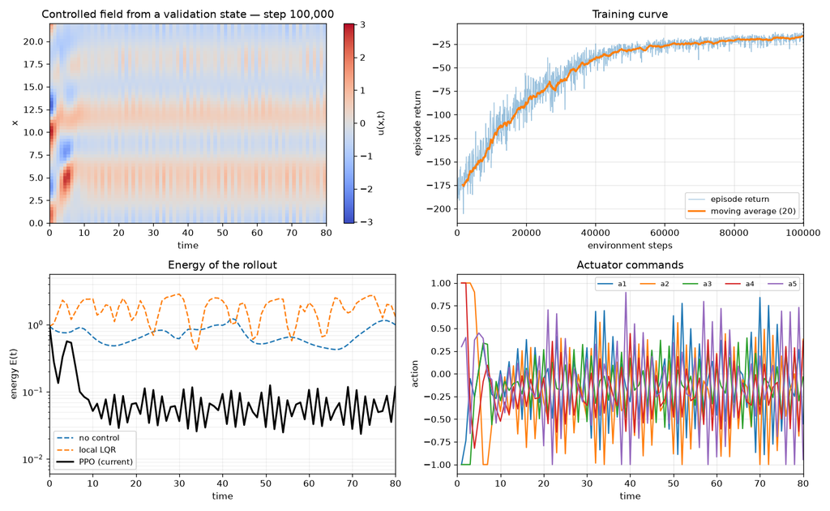

**What Stage 1 established** and the later stages keep: the Gymnasium interface, three algorithms with one set of settings, deterministic evaluation on unseen cases, and a classical reference beside the learned one.

### Stage 2: Gust control with a thin-airfoil model

Stage 2 poses the gust problem of the previous section with the cheapest aerodynamics there is, C_L = 2πα with a simple drag polar, and the two lags. TD3 trained for 50,000 steps (about 145 s) brought the lift RMSE on the test gust from 0.139 without control to 0.017. The experiments are where the formulation was learned: PPO, TD3 and SAC on the same five gusts (0.0083, 0.0165, 0.0257); removing the gust angle from the observation did not hurt (0.0139 against 0.0165), because feedback from the lift was enough; a flap five times slower tripled the error of the trained policy (0.051) until it was retrained (0.021); an agent trained on weak gusts failed on strong ones (0.047 against 0.014); and a larger drag weight lowered the mean drag by 2 % at a cost in tracking.

[figure not shown]

**One gust, one flight.** Lift, flap angle and gust angle over the 6-second episode for the Stage 2 controller: the uncontrolled lift rises to about 1.02, the trained policy keeps it between 0.50 and 0.59 by deflecting the flap to about −8° as the gust angle peaks at 4.8°.

[figure not shown]

**The two-line lift law.** Thin-airfoil theory gives the lift slope but not the camber's lift at zero incidence, and nothing about stall or the Reynolds number. Stage 3 replaces this box with a function learned from RANS data; Stage 4 keeps everything around it.

Nothing after Stage 2 changes the formulation: the observation, the action, the reward, the gusts and the episode are the same in Stage 4. Only the aerodynamic function changes. That separation is what makes the exchange a one-line edit in the environment, and it is also why the learned controller has to be examined again afterwards: a different environment defines a different optimum, and an agent will find the weak spots of whichever environment it is given.

## Method

### Stage 3: the surrogate

The network is a multilayer perceptron with layers of 64, 64 and 32 tanh units, five standardised inputs (Re/10⁶ among them) and two standardised outputs, trained with Adam at 10⁻³ on the mean squared error, batch 32, with 15 % of the training rows held out for early stopping (patience 40, best weights restored). Inputs and outputs are scaled separately on the training cases only, and every metric is computed in physical units after undoing the output scaling. Thin-airfoil theory is the physical reference for lift; a mean predictor is the statistical one.

[figure not shown]

**Five inputs, two outputs, 6,690 weights.** The scalers travel with the network: the saved surrogate is the network plus its two scalers, and Stage 4 loads all three together.

### Stage 4: the environment and the agents

The Stage 4 environment is the Stage 2 environment with its aerodynamic function replaced by the surrogate. Because the agent calls that function at every one of its 50,000 training steps, I re-implemented the forward pass of the saved Keras network in NumPy and checked it against Keras to 3 × 10⁻⁷: one call fell from 16.7 ms to 0.012 ms, which turned a 14-minute overhead per training run into 0.6 s. The agents are from Stable-Baselines3 with the settings fixed in Stages 1 and 2: SAC as the main agent (learning rate 3 × 10⁻⁴, buffer 100,000, batch 256), PPO (3 × 10⁻⁴, 1,024 steps per update, batch 64) and TD3 (10⁻³, action noise 0.1), all with γ = 0.99 and 50,000 steps.

### How I evaluated

- **Controller:** the deterministic policy on five fixed gusts (the training gust +2.5 m/s for 1.3 s and four others, two of them stronger than anything seen in training), scored by the lift RMSE over the flight and always beside the uncontrolled flight on the same gusts.
- **Validity:** the equivalent angle is monitored against the trusted range read from the training data (−4.91° to 14.84°), and the fraction of steps outside it is reported for every flight.
- **Surrogate:** MAE, RMSE and R² per coefficient on the 111 held-out simulations; architectures, inputs and data size compared over three seeds each; an emulated extrapolation test in Re and α; a five-member ensemble whose spread is checked against the error.
- **Robustness of the conclusions:** Stage 4 was executed twice, once with a surrogate retrained by the Stage 3 code and once with the surrogate file originally supplied with the problem, and every conclusion was checked against both.

## Implementation

What was run, and with what.

[output not shown]

One detail turned out to matter more than any setting. The surrogate file that Stage 4 loads is not the network that Stage 3 retrains when it runs; it is the output of an earlier run of the same code, supplied with the problem. The two score differently on the same 111 test cases and give 0.7595 and 0.7705 for the same query. I scored both, used the supplied file for the controller, and kept the retrained run as the second execution that the robustness check relies on.

## Results 1 — The aerodynamic function (Stage 3)

Test scores in physical units. The same code and seed on a different machine moved lift and drag accuracy in opposite directions, by about the spread between seeds.

| 111 test simulations | Supplied surrogate (used in Stage 4) | Retrained, seed 7 | Seeds 0, 1, 2 |
| --- | --- | --- | --- |
| C_L RMSE / R² | 0.0259 / 0.9979 | 0.0209 / 0.9986 | 0.0236 ± 0.0038 |
| C_D RMSE / R² | 0.00087 / 0.972 | 0.00100 / 0.963 | 0.00080 ± 0.00015 |
| Thin-airfoil C_L RMSE (reference) | 0.360 | 0.360 | — |
| C_L, C_D at Re 4 × 10⁶, α 5°, NACA 2412 | 0.7595, 0.00967 | 0.7705, 0.00973 | — |

The network reproduces RANS lift to about 0.02 and drag to about 0.001 on simulations it never saw, where thin-airfoil theory is off by 0.36 in lift. The experiments asked what that depends on:

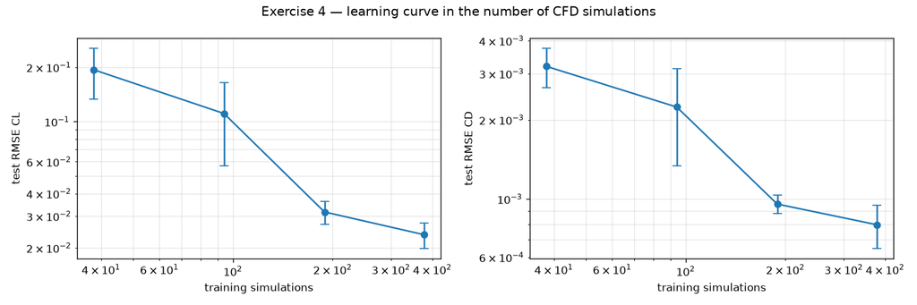

**Scarce data.** Mean lift RMSE over three seeds against the number of training simulations: the error falls steeply up to about 190 cases and slowly after that; below 100 cases the drag R² drops to 0.62 and the results vary strongly between seeds.

**Extrapolation.** Ratio of the test error outside an emulated training band to the error inside it: leaving the Reynolds band multiplies the error by 1.8 (lift) to 2.5 (drag); leaving the angle band by 2.3 and 5.6. R² stays above 0.98 for lift outside both bands, a reminder that R² over a wide range can hide a doubled error.

- **Capacity bought nothing.** A 32-32 network (1,314 weights) scored 0.0174 ± 0.0017 in lift RMSE against 0.0236 for the 64-64-32 reference and 0.0260 for 128-128-64; with 378 cases the smallest network is at least as good.
- **The Reynolds number carries real information**, more for drag than for lift: without it, lift RMSE rose 27 % and drag RMSE 47 %.
- **An ensemble of five halves the lift error** (0.0129 against 0.0245 for an average member). Its spread tracks the drag error (Spearman 0.53) but hardly the lift error (0.11) inside the data, and doubles to quadruples outside it, so the spread is a flag for extrapolation rather than an error bar.

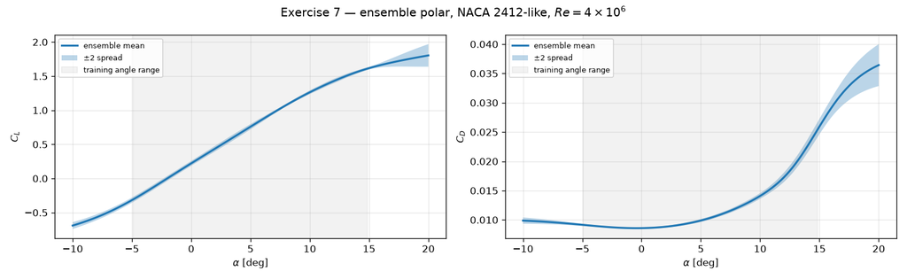

## Results 2 — The flap controller (Stage 4)

This is the result the project was built for. With the surrogate in the loop, the main SAC agent brought the lift RMSE on the training gust from 0.135 without control to 0.060, and over the five-gust suite from 0.150 to 0.054. PPO and TD3, trained with the same budget and settings, did better in this run: 0.0098 and 0.0188, with the equivalent angle held within about a degree of 5°, which means they cancelled most of each gust. Each algorithm was trained once, so the ranking is what one run shows, not a property of the algorithms.

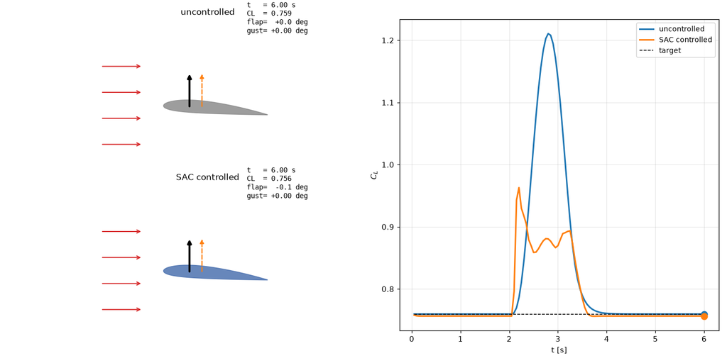

**A flight through the training gust.** Lift against its target over the 6-second episode, uncontrolled and with the Stage 4 SAC controller. Without control the lift rises to 1.21; the controller holds it near 0.87 to 0.90 through the gust and is back on target at 3.7 s. The spike to 0.96 at the onset is the wrong-direction first move discussed below.

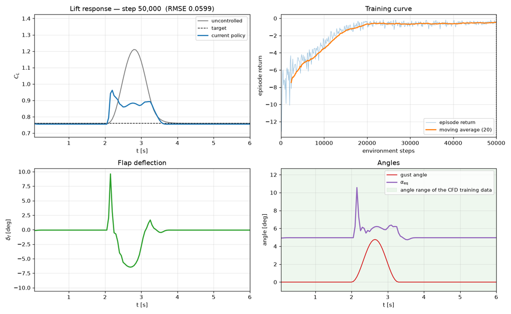

[figure not shown]

**The same three algorithms on the three problems of this project.** Stage 1: cost over 20 unseen chaotic states; Stage 2 and Stage 4: mean lift RMSE over the same five gusts. Lower is better in every panel, one trained model per bar. The ranking does not carry over between problems: the off-policy models were far ahead on the chaotic field, PPO ahead and SAC behind on both airfoil models.

### What changed when the aerodynamics became real

The controller formulation is identical in Stages 2 and 4, so the two can be set side by side. The target lift moved from 0.548 (thin-airfoil theory ignores the camber) to 0.760 (the surrogate's zero-gust value), and the lift slope from 6.28 to 6.51 per radian. Agents trained on either model were tested on both:

Mean lift RMSE over the five gusts. Each agent did best on its own model, and the surrogate-trained agent barely beat no control on the other: an agent moved to another model is asked for a lift it never saw. One seed per agent, so the size of the effect is not resolved.

| SAC agent, same seed and budget | Tested on the surrogate (Stage 4) | Tested on thin-airfoil theory (Stage 2) |
| --- | --- | --- |
| Trained on the surrogate | 0.054 | 0.144 |
| Trained on thin-airfoil theory | 0.061 | 0.051 |
| No control | 0.150 | 0.151 |

[figure not shown]

**Same gust, two algorithms, opposite first reactions.** The flap moves at the gust onset in both the Stage 2 (TD3) and Stage 4 (SAC) runs, but the SAC policy first deflects it the wrong way, to +9.6°, lifting C_L to 0.96 against a target of 0.76 before reversing. A timing test alone would have called this a success; the trace exposed it, and it repeated in both executions of Stage 4, so it belongs to SAC with this seed rather than to the surrogate.

### Where the agent drives the surrogate

[figure not shown]

**Only the strong-gust runs leave the trusted band, and the unprotected agent leaves it furthest.** Range of the equivalent angle over each set of evaluation flights; bars in red leave the band read from the training data. With gusts up to ±6 m/s the gust alone drives the uncontrolled airfoil to 17.2°; the agent trained without a penalty went to 19.9° and spent 4.6 % of its steps outside the data, more than doing nothing (2.1 %); a quadratic penalty on leaving the band cut that to 0.8 % and, in this run, tracked better (0.213 against 0.261).

This is the exploitation one should expect from a learning agent, and it is why extrapolation is more dangerous inside a reinforcement-learning loop than in a single prediction: the agent searches for the places where the model errs in its favour; it does not merely stumble on them.

### Sensitivity to the operating point

Stage 4 experiments 3, 4, 5 and 7.

[output not shown]

## Results 3 — What a second execution taught me

I ran Stage 4 twice with the same seeds: once with the surrogate retrained in my own Stage 3 run and once with the file originally supplied with the problem. The two surrogates differ by 0.011 in lift at the operating point, within the spread between training seeds. That small difference was enough to reverse four of eight conclusions.

Mean lift RMSE over the five-gust suite unless stated. The results that held are the ones with a large effect or a mechanism behind them; the ones that reversed are single-seed comparisons between SAC runs.

| Result | Execution with the retrained surrogate | Execution with the supplied surrogate | Status |
| --- | --- | --- | --- |
| PPO is the best of the three algorithms | 0.0128 | 0.0098 | held |
| The domain penalty keeps the agent inside the data (fraction of steps outside, penalised vs unprotected) | 0.0167 vs 0.0375 | 0.0083 vs 0.0458 | held |
| An effort weight of 0.2 makes the controller timid | 0.202 | 0.145 (no control 0.150) | held |
| SAC's first flap move is in the wrong direction | +8.99° | +9.61° | held |
| SAC trained on the surrogate beats SAC trained on thin-airfoil theory, on the surrogate | 0.080 vs 0.063 | 0.054 vs 0.061 | reversed |
| A drag weight of 1.0 helps tracking | 0.057 vs 0.080 | 0.064 vs 0.054 | reversed |
| Random Re in training helps | 0.073 vs 0.079 | 0.089 vs 0.054 | reversed |
| NACA 4412 and 4415 are controlled | 0.161 and 0.143, worse than no control | 0.063 and 0.046, better | reversed |

## Key observations

1. **The controller works, and the cost argument holds.** Inside the surrogate environment the learned flap controller holds the lift to within 0.01 to 0.05 of its target through gusts, against 0.15 without control; one agent makes 50,000 aerodynamic queries and trains in 11 s to 165 s, where the solver in the loop would take about 35 days.
2. **A small network is enough for the coefficients.** 1,314 to 6,690 weights reproduce RANS lift to about 0.02 and drag to about 0.001 on unseen cases; more capacity bought nothing on 378 simulations, and the learning curve flattens after about 190.
3. **The cheap call path is not optional.** Keras `predict` at 16.7 ms per call would have cost five times the whole training time; the same weights in NumPy cost 0.012 ms. Checking that the two agree to 3 × 10⁻⁷ is what makes the shortcut safe.
4. **An agent will exploit the model.** Without a penalty the agent spent more than twice as long outside the data as doing nothing. The trusted range has to be read from the data, monitored on every flight and enforced in the reward.
5. **The policy extrapolates too, in its own observations.** On sections whose target lift was far from the one it trained on, the controller was worse than no control although every surrogate input stayed inside the data.
6. **Traces catch what summary numbers hide.** The SAC policy moved the flap at the right time and in the wrong direction; only the flap trace showed it.
7. **Repeat before you rank.** Four of eight conclusions reversed between two executions that differed by less than the seed spread of the surrogate. The ones that held had a mechanism behind them.

## Conclusion

A flap controller can be trained by deep reinforcement learning inside an aerodynamic model that CFD built once. The 6,690-weight surrogate is accurate to about 0.02 in lift on unseen cases and costs 0.012 ms per call, and the controllers trained on it hold the lift through gusts to within 0.01 to 0.05, against 0.15 without control. The surrogate does not replace CFD as the source of truth; it replaces repeated CFD calls. The solver keeps two jobs, building a database good enough to train on and validating the final controller on a model the agent never trained on, and the second is the step this project does not take.

The limits were as instructive as the numbers. The surrogate is trustworthy only inside its data and the agent will look for the edge; the policy generalises only as far as the observations it has seen; and conclusions drawn from single training runs do not survive a second execution. Part 2 of this series builds a second aerodynamic function from the same simulations, through compressed flow fields rather than fitted coefficients, uses it for a design search, and puts it into this same environment with three seeds per configuration to see whether the controller notices the difference.

The concepts behind each stage, from the learning loop to the algorithms and the surrogate in the loop, are drawn step by step in Deep Reinforcement Learning for Flow Control: A Visual Guide.

Continue to Part 2: reduced-order models, a β-VAE and a latent-space design search →

## Code, data and reproducibility

The four notebooks of the repository.

| Notebook | Stage |
| --- | --- |
| `01_ks_control_gymnasium.ipynb` | Stage 1 — Control of a chaotic field: the method |
| `02_airfoil_gust_control_thin_airfoil.ipynb` | Stage 2 — Gust control with a thin-airfoil model |
| `03_airfrans_cfd_surrogate.ipynb` | Stage 3 — A CFD surrogate from AirfRANS |
| `04_airfoil_gust_control_cfd_surrogate.ipynb` | Stage 4 — The flap controller trained inside the surrogate |

[output not shown]